# Project_Notes

G Perkins

June 5, 2019

# EPR: Project Notes

The dataset provide as part of environment reporting legislation in pdf format and has been transposed to an excel. Detailed information about the program can be found here https://www2.gov.bc.ca/gov/content/environment/waste-management/recycling/product-stewardship

This indicator will be replacing the tire recycling indicator https://www2.gov.bc.ca/gov/content/environment/research-monitoring-reporting/reporting/environmental-reporting-bc/sustainability-indicators

## Data summary:

There are seven sets of data assessed for this indicator;

- Beverage containers
- Oil
- Tires
- Paint-Flam_Pest (pfp)
- Elect
- Lead-Acid Batteries
- Packaging and Printed Paper (ppp)

This data was combined with BC population data to calculate per person values per region. BC population data was manualy extracted per regional district for 2000 - 2018 using the BC Stats tool: https://www.bcstats.gov.bc.ca/apps/PopulationEstimates.aspx

Broadly, each of the above indicators has data on 1) quantity of items (kgs/litres) per regional district, 2) financial and 3) units moved. Finanial and unit data is compiled at the provincial scale (aspatial).

Not all indicators had available data on these three catergories and collection years vary per indicator.

Some changes to regional district names and associations (merging) was also addressed. This included updating regional district names (Queen Charlotte skeena to North Coast, Power river to Qathet, joining Comox and Strathcona into a single region)

## Work flow:

1. All raw data is extracted from the excel worksheets and combined into a three dataframes using the ‘clean.readxl.R’ script. The dataframes are ‘all.finance’, ‘all.units’, ‘all.regions’
2. Data is then loading into R and inital summaries and exploration is conducted using the ‘01_load.R’ script
3. To be continued……

** Note: during this process when typos and errors were found in the original datasets manual updates were made and marked in highlighter to correct or double check with data custodian.

## 1) Beverage containers

Collected from multiple groups: Encorp Pacific (Canada), BC Brewers Recycles Collection Council. Both of these collect data on the units collected, weight collection (tonnes) with population data from 2006 - 2017. There is also some financial data ( revenue/ expenditure /deposits charged / units moved) and other (CO2 Equivalent Reduced (tonnes), weight of material)

Data exploration points to consider:

- Regional and financial data grouped for Encorp and BCBRCC
- BCBRC years are different (2007/08, 2008/09,2009/10) as BCBRCC reported to financial years (March 31st) over this period. In these cases data was assigned to preceeding year.
- In Encorp data Comox and Strathcona joined (2007 to 2010), then split into two seperate regions from 2011 onwards. These are recorded seperately for BRCC.
- Some data anomolied in Central Coast and Central Kootneys in 2015 were verified in pdf reports and found to be same as pdf report.

#### Regional data exploration

Note I still need to edit the comox Strathcona regions.

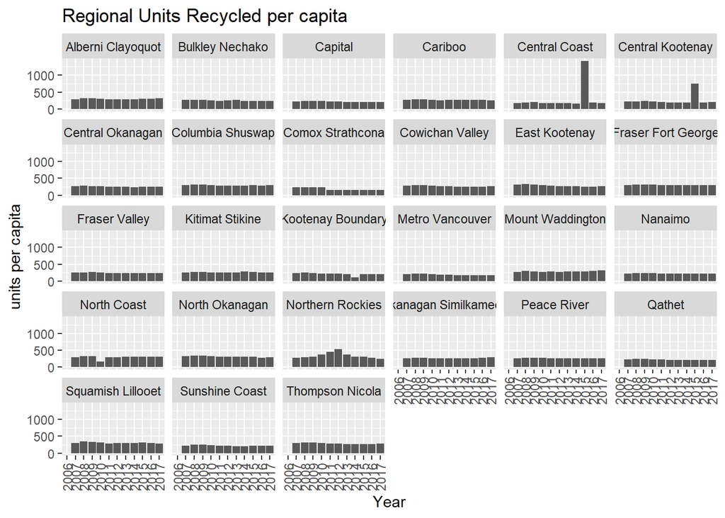

```r
# Units per capita
ggplot(units.per.cap, aes(year,n.pop)) +
      facet_wrap(~ regional_district) +
      geom_bar(stat = "identity",position = "dodge") +
      labs(title = "Regional Units Recycled per capita",
           x = "Year", y = "units per capita") +
      theme(axis.text.x = element_text(angle = 90,vjust=0.5))
```

This plot indicates some data anomolies in the 2015 datasets forthe central coast and Central Kootneys. After verifying with the original data https://www2.gov.bc.ca/assets/gov/environment/waste-management/recycling/recycle/beverage-containers/ar/bdl/2015_bdl_annual_report.pdf this appears the original data and true is same as pdf report

More intresting is the divergence from the BC average to enable regions to see how they compare to the provincial average (above or below).

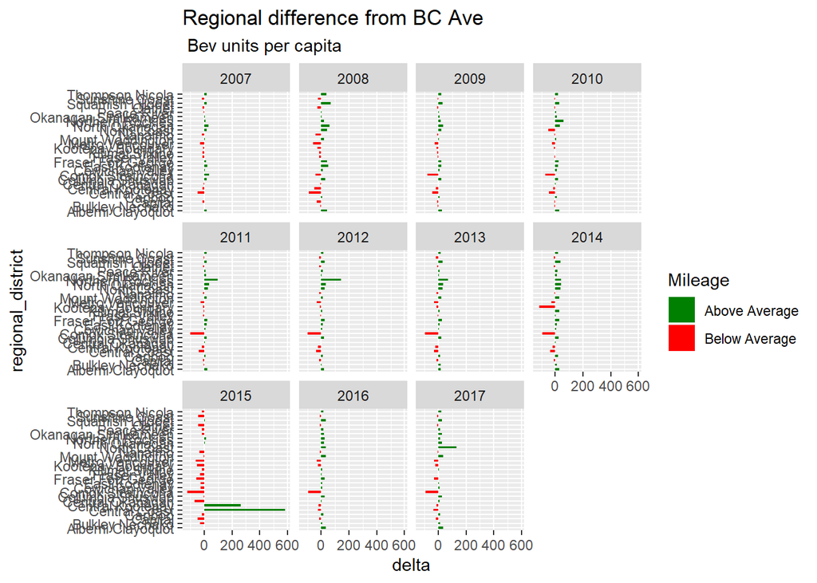

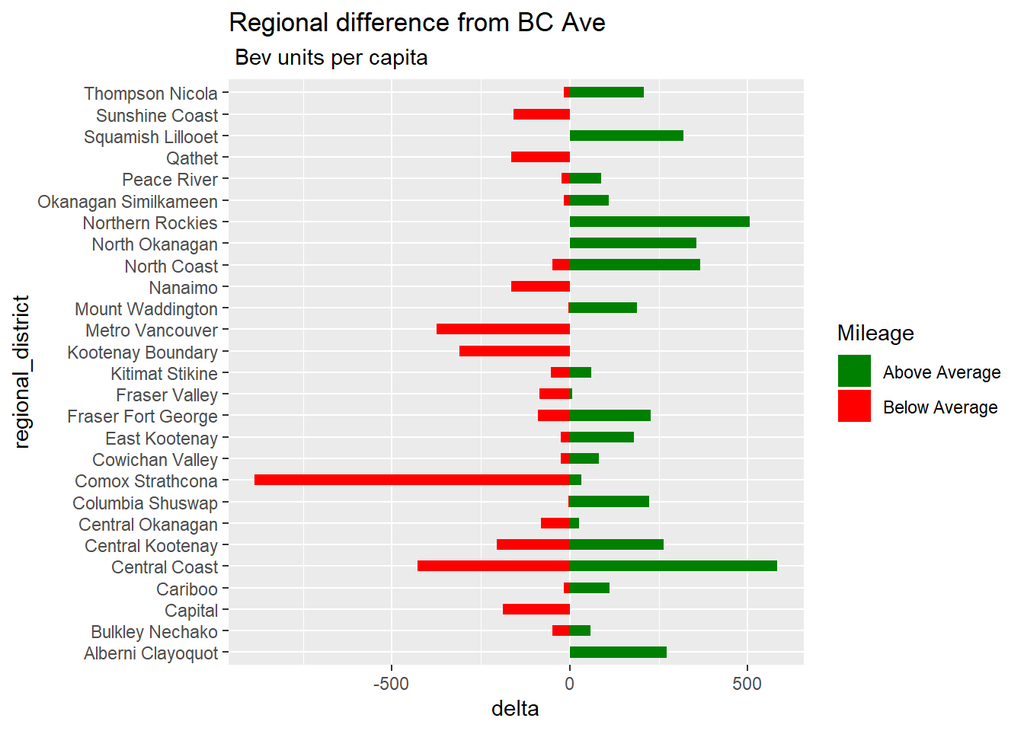

#### Finance data (provincial)

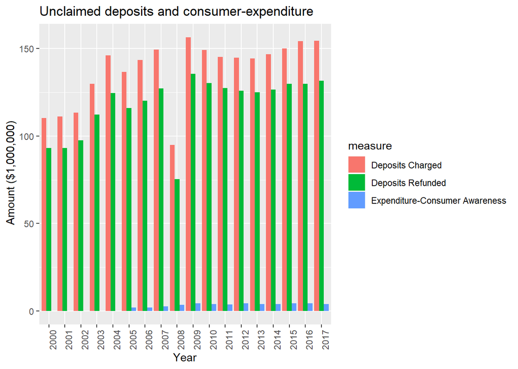

There is not a strong correlation between with awareness, may need to adjust this per unit? or check if the awareness expenditure is for multiple programs (ECPOR and BCRCCC). Perhaps a comparison of revenue vs expenditure on education programs should be looked at?

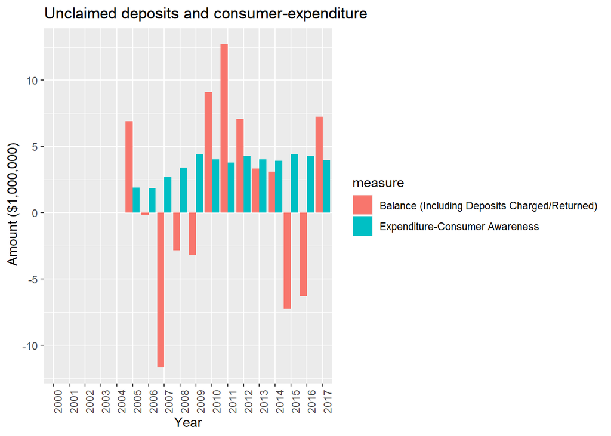

?? not sure what is going on here?

#### Units Moved

Is there a difference in the units moved (recovered or sold over time?)

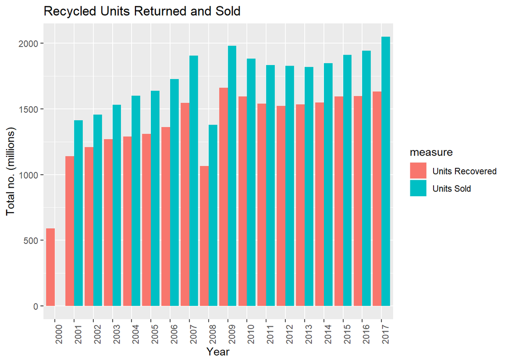

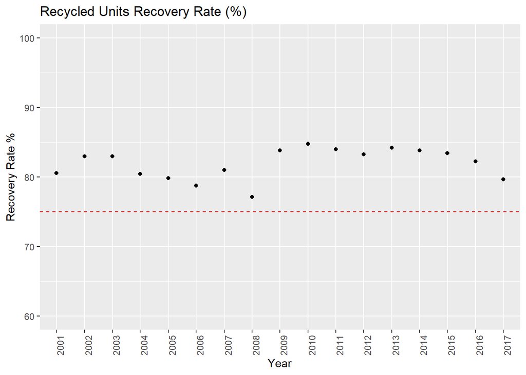

Thoughts on Beverage recycling:

# 2) Lubricating Oil, Filters and containers.

Collection broken in regional and temporal data sets from 2010 to 2017 including:

- Used oil (litres per person)
- Used filters (kg per person)
- Containers (kg per person)
- Antifreeze (kg person)

Data exploration points to consider:

Temporal and a-spatial data sets include financial, collection sites, units moved, and end fate for products. Collection sites does not look like much change in trends over time? Could be opportunity to combine a number of measure (ie beverage together). Comox and Strathcona are treated separately in this analysis.

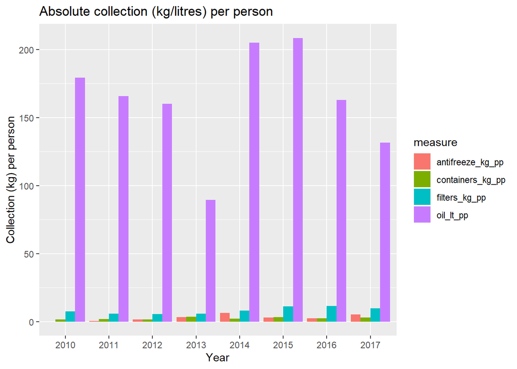

Used oil is a magnitude difference in volume. Repeat graph with out used oil values:

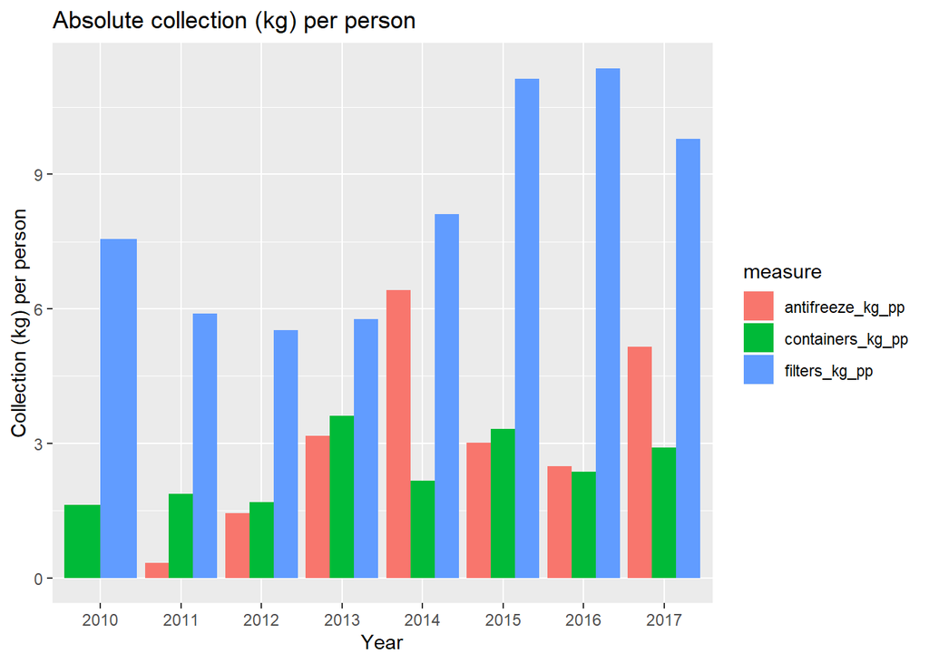

This may be due to a number of data values being high / errors